# Cómo influye en los estudiantes universitarios de la UTEC la modalidad híbrida implementada en el ciclo 2022-1

#### Librerías e instalación

## Introducción

### Relevancia

Con la llegada de la nueva modalidad híbrida en las universidades, específicamente en la UTEC en el ciclo 2022-1, una nueva modalidad de aprendizaje donde se le da la opción al alumno de llevar sus clases de manera presencial o virtual. Gracias a esta opción, el aprendizaje se puede adaptar a las necesidades o los gustos de cada estudiante. Por ello vemos necesario el realizar esta encuesta donde podamos analizar las preferencias y dificultades para poder entender las necesidades colectivas que presenta la comunidad universitaria de la UTEC, permitiendo a los directivos y docentes tener una visión más directa de la realidad que viven sus estudiantes en una modalidad u otra.

### Objetivos

- Analizar las preferencias de los estudiantes sobre ambas modalidades de aprendizaje.
- Analizar las dificultades que puedan presentar los estudiantes según cada modalidad
- Analizar los aspectos de la rutina del estudiante que se ven afectados por cada modalidad.
- Recolectar información útil para poder enfocar de mejor manera las dificultades que puedan tener los estudiantes y encontrarles una solución adecuada.

### Planificación

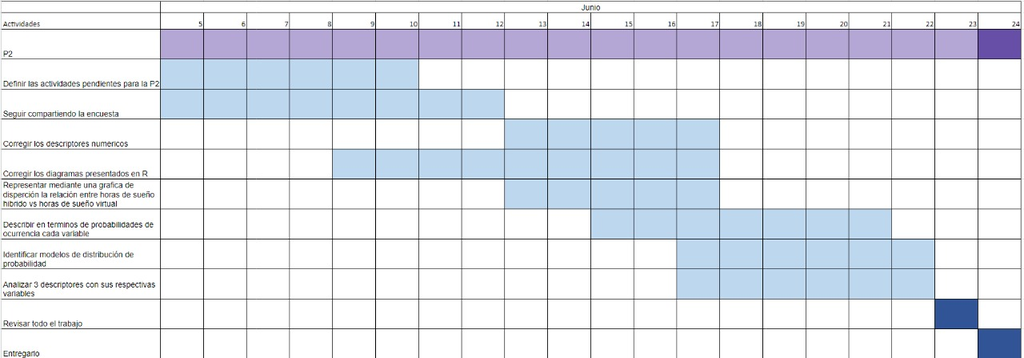

Diagrama de Grant

## Datos

### Recolección de datos

La recolección de datos se realizó mediante una encuesta, la cual requirió la elaboración de un cuestionario con un número de preguntas menor que 20. El cuestionario fue elaborado de manera que se garantice una tasa de respuestas elevada, y asegurar la calidad de las respuestas. Las encuestas fueron enviadas mediante correo a los estudiantes de la Universidad de Ingeniería y Tecnología (UTEC).

Los datos se cargan del archivo de encuestados, exportado de Google Forms:

```r
DF <- read_csv("S1EncuestadosFINAL.csv", locale = locale(encoding="UTF-8"))
```

### Población, muestra y muestreo

Al tratarse de una población extensa, se decidió escoger una muestra de 200 estudiantes de distintas carreras pertenecientes a UTEC, los cuales han sido escogidos por medio de un muestreo estratificado basado en carrera. En base a la siguiente tabla de estudiantes matriculados durante 2021-1, podemos estimar la proporción de muestras que necesitamos de cada carrera:

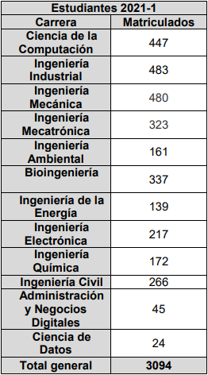

Tabla de cantidad de estudiantes matriculados durante 2021-1

### Variables

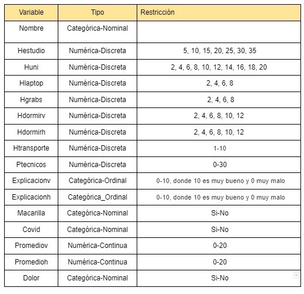

#### Variable categóricas

- Preferencia: Refiere a la modalidad de preferencia del encuestado, sea virtual o presencial híbrida.

#### Variables numéricas

- Horas.de.Estudio: Cantidad de horas de estudio del encuestado, fuera de clases, por semana.
- Horas.en.Universidad: Cantidad de horas de estancia en la universidad, por semana.
- Horas.en.Computadora: Cantidad de horas en uso de una laptop o computador, por semana.
- Horas.en.Grabaciones: Cantidad de horas del encuestado viendo clases grabadas.
- Horas.Dormir.Virtual = Cantidad de horas de dormir del encuestado en modalidad virtual, por semana.
- Horas.Dormir.Presencial = Cantidad de horas de dormir del encuestado en modalidad presencial híbrida por semana.
- Horas.Transporte = Cantidad de horas que el encuestado pasa en medios de transporte para llegar a la universidad.
- Problemas.Tecnicos = Cantidad de problemas técnicos que el encuestado ha tenido durante un mes.

### Limpieza de base de datos

#### Renombrando variables

Para poder limpiar la data, hay que cambiar el nombre de las variables a algo más sencillo de entender:

```r
names(DF)
```

```
##  [1] "Marca temporal"
##  [2] "Dirección de correo electrónico"
##  [3] "Nombre"
##  [4] "Ciclo"
##  [5] "¿Prefieres el modo hibrido o virtual?"
##  [6] "¿Cuántas horas en promedio pasas estudiando, fuera de tus clases, a la semana?"
##  [7] "¿Cuántas horas en promedio pasas en la universidad a la semana?"
##  [8] "¿Cuántas horas en promedio pasas usando la computadora o laptop al día?"
##  [9] "¿Cuántas horas en promedio pasas revisando grabaciones de clases a la semana?"
## [10] "¿Cuántas horas en promedio duermes al día siguiendo una modalidad virtual?"
## [11] "¿Cuántas horas en promedio duermes al día siguiendo una modalidad hibrida?"
## [12] "¿Cuántas horas en promedio pasas en medios de transporte desde o hacia la universidad al día?"
## [13] "¿Qué tantos problemas técnicos presentas al mes en clases virtuales?"
## [14] "¿Consideras que se escucha bien a los profesores en las clases virtuales?"
## [15] "¿Qué calificación le das a las explicaciones de tus profesores en la modalidad virtual?"
## [16] "¿Qué calificación le das a las explicaciones de tus profesores en la modalidad presencial?"
## [17] "¿Te incomoda usar mascarilla?"
## [18] "¿Te has contagiado de COVID-19 después del periodo de asistencia presencial a la universidad?"
## [19] "¿Consideras que en la universidad se cumplen los reglamentos de bioseguridad?"
## [20] "¿Cuál fue tu promedio en clases virtuales?"
## [21] "¿Cuál es tu promedio en clases hibridas hasta ahora?"
## [22] "¿Has presentado dolores de espalda durante las clases virtuales?"
## [23] "¿En que modalidad consideras que mantienes una alimentación más sana?"
## [24] "¿En que modalidad consideras que prestas más atención a las clases?"
## [25] "¿En que modalidad consideras que tienes más comodidad trabajando en grupo?"
## [26] "¿En que modalidad consideras que presentas más estrés durante el periodo de estudios?"
```

Empezamos renombrando las variables y agregando etiquetas correspondientes a las preguntas de la encuesta:

```r
DF %>% rename(
  Preferencia = "¿Prefieres el modo hibrido o virtual?",
  Horas.de.Estudio = "¿Cuántas horas en promedio pasas estudiando, fuera de tus clases, a la semana?",
  Horas.en.Universidad = "¿Cuántas horas en promedio pasas en la universidad a la semana?",
  Horas.en.Computadora = "¿Cuántas horas en promedio pasas usando la computadora o laptop al día?",
  Horas.en.Grabaciones = "¿Cuántas horas en promedio pasas revisando grabaciones de clases a la semana?",
  Horas.Dormir.Virtual = "¿Cuántas horas en promedio duermes al día siguiendo una modalidad virtual?",
  Horas.Dormir.Presencial ="¿Cuántas horas en promedio duermes al día siguiendo una modalidad hibrida?",
  Horas.Transporte = "¿Cuántas horas en promedio pasas en medios de transporte desde o hacia la universidad al día?",
  Problemas.Tecnicos = "¿Qué tantos problemas técnicos presentas al mes en clases virtuales?",
  Calidad.Sonido = "¿Consideras que se escucha bien a los profesores en las clases virtuales?",
  Calificacion.Clase.Virtual = "¿Qué calificación le das a las explicaciones de tus profesores en la modalidad virtual?",
  Calificacion.Clase.Presencial = "¿Qué calificación le das a las explicaciones de tus profesores en la modalidad presencial?",
  Comodidad.Mascarilla = "¿Te incomoda usar mascarilla?",
  Contagio.COVID = "¿Te has contagiado de COVID-19 después del periodo de asistencia presencial a la universidad?",
  Cumplimiento.Reglamento = "¿Consideras que en la universidad se cumplen los reglamentos de bioseguridad?" ,
  Promedio.Virtual = "¿Cuál fue tu promedio en clases virtuales?",
  Promedio.Presencial = "¿Cuál es tu promedio en clases hibridas hasta ahora?",
  Dolor =  "¿Has presentado dolores de espalda durante las clases virtuales?",
  Preferencia.Alimentacion = "¿En que modalidad consideras que mantienes una alimentación más sana?",
  Preferencia.Atencion =  "¿En que modalidad consideras que prestas más atención a las clases?",
  Preferencia.Trabajos.Grupales =  "¿En que modalidad consideras que tienes más comodidad trabajando en grupo?",
  Modalidad.de.Mayor.Estres = "¿En que modalidad consideras que presentas más estrés durante el periodo de estudios?"
) -> DF
```

#### Datos faltantes

No tenemos muchos datos faltantes, así que aprenderemos a vivir con eso.

```r
round(sum(is.na(DF))/(nrow(DF)*ncol(DF))*100,2)
```

```
## [1] 0.31
```

#### Observaciones faltantes

Es posible eliminar las obs. pero puede ser problemático, así que no lo eliminaremos.

```r
round(sum(!complete.cases(DF))/nrow(DF)*100,2)
```

```
## [1] 4.74
```

#### Recategorización de variables

Aquí estamos observando como son nuestras variables.

```r
summary (DF)
```

```
##  Marca temporal     Dirección de correo electrónico    Nombre
##  Length:211         Length:211                      Length:211
##  Class :character   Class :character                Class :character
##  Mode  :character   Mode  :character                Mode  :character
##
##
##
##
##      Ciclo       Preferencia        Horas.de.Estudio Horas.en.Universidad
##  Min.   : 1.00   Length:211         Min.   : 2.000   Min.   : 2.000
##  1st Qu.: 3.00   Class :character   1st Qu.: 6.000   1st Qu.: 4.000
##  Median : 4.00   Mode  :character   Median : 8.000   Median : 8.000
##  Mean   : 4.27                      Mean   : 7.896   Mean   : 8.948
##  3rd Qu.: 5.00                      3rd Qu.:10.000   3rd Qu.:12.000
##  Max.   :10.00                      Max.   :16.000   Max.   :20.000
##
##  Horas.en.Computadora Horas.en.Grabaciones Horas.Dormir.Virtual
##  Min.   : 4.000       Min.   : 2.000       Min.   : 2.00
##  1st Qu.: 8.000       1st Qu.: 4.000       1st Qu.: 6.00
##  Median :10.000       Median : 6.000       Median : 8.00
##  Mean   : 9.488       Mean   : 6.957       Mean   : 7.64
##  3rd Qu.:12.000       3rd Qu.: 8.000       3rd Qu.: 8.00
##  Max.   :12.000       Max.   :20.000       Max.   :12.00
##
##  Horas.Dormir.Presencial Horas.Transporte Problemas.Tecnicos Calidad.Sonido
##  Min.   : 2.000          Min.   : 2.000   Min.   : 5.000     Length:211
##  1st Qu.: 6.000          1st Qu.: 2.000   1st Qu.: 5.000     Class :character
##  Median : 6.000          Median : 2.000   Median : 5.000     Mode  :character
##  Mean   : 6.708          Mean   : 3.114   Mean   : 6.786
##  3rd Qu.: 8.000          3rd Qu.: 4.000   3rd Qu.: 5.000
##  Max.   :12.000          Max.   :10.000   Max.   :25.000
##  NA's   :2               NA's   :1        NA's   :1
##  Calificacion.Clase.Virtual Calificacion.Clase.Presencial Comodidad.Mascarilla
##  Min.   : 1.000             Min.   : 1.000                Length:211
##  1st Qu.: 4.000             1st Qu.: 3.000                Class :character
##  Median : 7.000             Median : 8.000                Mode  :character
##  Mean   : 6.114             Mean   : 6.265
##  3rd Qu.: 8.000             3rd Qu.: 9.000
##  Max.   :10.000             Max.   :10.000
##
```

[output cut: 9 more lines]

```
##  Length:211          Length:211         Length:211
##  Class :character    Class :character   Class :character
##  Mode  :character    Mode  :character   Mode  :character
##
##
##
##
##  Preferencia.Atencion Preferencia.Trabajos.Grupales Modalidad.de.Mayor.Estres
##  Length:211           Length:211                    Length:211
##  Class :character     Class :character              Class :character
##  Mode  :character     Mode  :character              Mode  :character
##
##
##
##
```

```r
DF$Correo <- NULL
DF$Tiempo <- NULL
DF$Nombre <- NULL
```

Observamos que las variables “Promedio.Presencial” y “Promedio.Virtual” variables categórica, así que las pasamos a numéricas. Cabe resaltar que este proceso también convierte algunos valores no deseados (“No sé”, “No tengo”, “????”) en NAs.

```r
DF$Promedio.Presencial %>% as.numeric %>% suppressWarnings -> DF$Promedio.Presencial
DF$Promedio.Virtual %>% as.numeric %>% suppressWarnings -> DF$Promedio.Virtual
```

De las variables “Promedio.Presencial” y “Promedio.Virtual” se eliminan los valores atípicos. Estos los encontramos observando las distribuciones de ambas columnas en diagramas de caja y bigote:

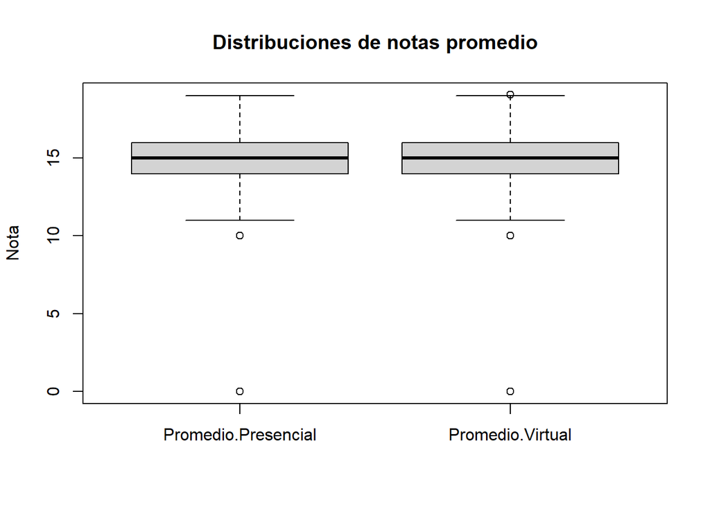

```r
DF[,c('Promedio.Presencial', 'Promedio.Virtual')] %>% boxplot(main="Distribuciones de notas promedio", ylab="Nota")
```

```r
DF[replace(DF$Promedio.Presencial == 0, is.na(DF$Promedio.Presencial == 0), FALSE), c('Promedio.Presencial')] <- NA
DF[replace(DF$Promedio.Virtual == 0, is.na(DF$Promedio.Virtual == 0), FALSE), c('Promedio.Virtual')] <- NA
```

Ahora, veremos las columnas correspondientes a las variables de tipo “Horas” (separadas en semanales y diarias):

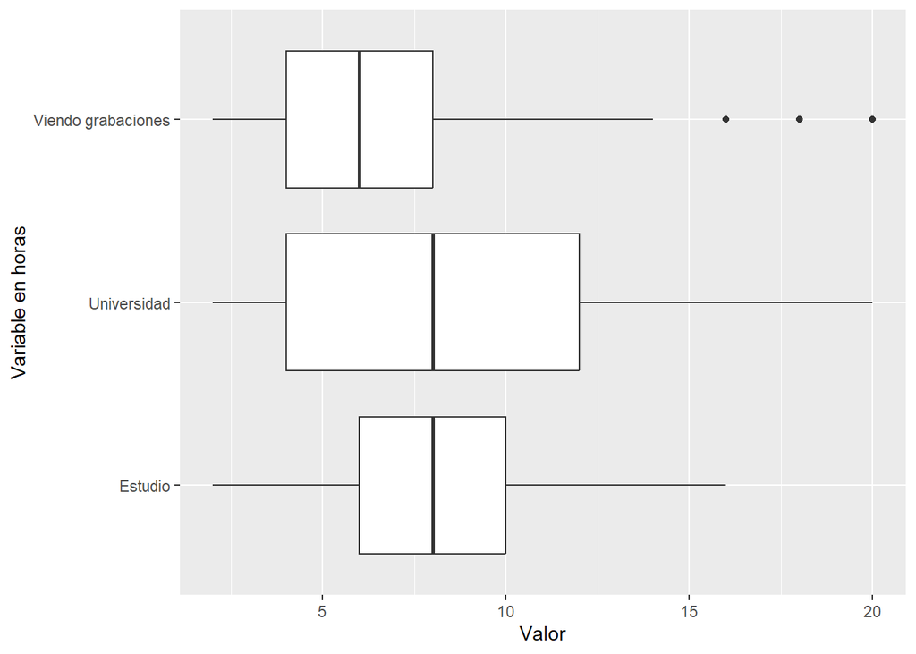

```r
Cols.Horas.Semanales <- c( 'Horas.de.Estudio', 'Horas.en.Universidad', 'Horas.en.Grabaciones' )

DF %>% melt( id.vars=integer(), measure.vars=Cols.Horas.Semanales ) %>% na.omit %>% ggplot( aes( x=variable, y=value ) ) +
  geom_boxplot() + coord_flip() + xlab('Variable en horas') + ylab('Valor') +
  scale_x_discrete( limits=Cols.Horas.Semanales,labels=c('Estudio', 'Universidad', 'Viendo grabaciones'))
```

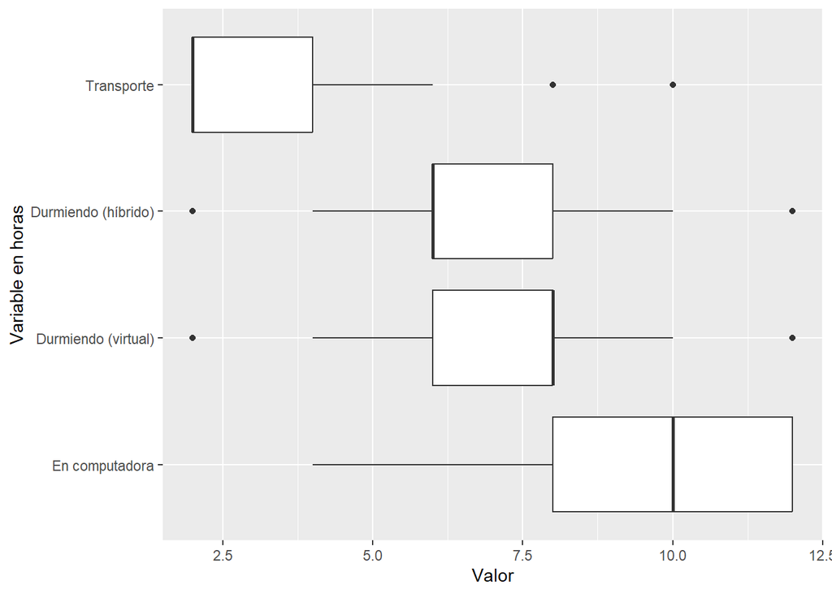

```r
Cols.Horas.Diarias <- c('Horas.en.Computadora', 'Horas.Dormir.Virtual', 'Horas.Dormir.Presencial', 'Horas.Transporte')

DF %>% melt( id.vars=integer(), measure.vars=Cols.Horas.Diarias ) %>% na.omit %>% ggplot( aes( x=variable, y=value ) ) +
  geom_boxplot() + coord_flip() + xlab('Variable en horas') + ylab('Valor') +
  scale_x_discrete( limits=Cols.Horas.Diarias,labels=c('En computadora', 'Durmiendo (virtual)', 'Durmiendo (híbrido)', 'Transporte'))
```

Dentro de las variables de horas semanales no hay valores atípicos notable. Por ejemplo, pasar 20 horas a la semana viendo grabaciones no es poco razonable si es que no se asiste a ninguna clase teórica, y pasar 20 horas a la semana en la universidad es posible con ciertos horarios de clase.

Una observación interesante es que hay personas que tienen un total de horas en actividades presenciales diarias mayor que 24:

```r
Cols.Horas.Diarias.Presencial <- c('Horas.en.Computadora', 'Horas.Dormir.Presencial', 'Horas.Transporte')
DF$Total.Horas.Diarias <- rowSums(DF[, Cols.Horas.Diarias.Presencial])

DF[DF$Total.Horas.Diarias > 24, c(Cols.Horas.Diarias.Presencial, 'Total.Horas.Diarias')]
```

| Horas.en.Computadora | Horas.Dormir.Presencial | Horas.Transporte | Total.Horas.Diarias |
| --- | --- | --- | --- |
| 12 | 10 | 4 | 26 |
| NA | NA | NA | NA |
| 10 | 8 | 8 | 26 |
| NA | NA | NA | NA |
| 10 | 10 | 6 | 26 |
| 12 | 6 | 8 | 26 |
| 12 | 8 | 6 | 26 |
| 12 | 12 | 4 | 28 |
| 12 | 6 | 10 | 28 |
| 12 | 12 | 2 | 26 |

Estas actividades no son necesariamente secuenciales. Por ejemplo, alguien puede dormir y/o usar su computadora en ciertos medios de transporte, especialmente si el viaje diario es tan largo como 3 a 4 horas por tramo, como sugiere la tabla. Por lo tanto, no se considera eliminar ninguna de estas filas.  
Sin embargo, sí se eliminan las filas que tengan valores nulos en estas columnas, ya que serán claves en el análisis que se realizará posteriormente.

```r
DF <- DF[ !is.na(DF$Total.Horas.Diarias), ]
DF$Total.Horas.Diarias <- NULL
```

Debido a un problema en la conversión de tipo de caracteres, es necesario reasignar el valor de “Sí” en la variable de “Cumplimiento.Reglamento” y “Comodidad.Mascarilla”.

```r
Reg <- DF$Cumplimiento.Reglamento == 'No'
DF[!Reg, c('Cumplimiento.Reglamento')] <- 'Sí'
Reg <- DF$Comodidad.Mascarilla == 'No'
DF[!Reg, c('Comodidad.Mascarilla')] <- 'Sí'
```

## Descriptores

### Descriptores númericos

Algunas variables numéricas fueron seleccionadas debido a que estas son las que más importan analizar para observar el efect del cambio de modalidad sobre el comportamiento y rendimiento de los estudiantes.

#### Descriptores de posición

*Media aritmética*

```r
Cols.Importantes <- DF[, c(
  'Horas.Dormir.Virtual',    #Hora que dormías en virtual
  'Horas.Dormir.Presencial', #Horas que duermes en hibrido
  'Horas.en.Universidad',        #Horas que pasas en la universidad
  'Horas.en.Computadora',        #Horas que pasas en la laptop
  'Horas.en.Grabaciones'         #Horas que pasas viendo las grabaciones
)]

Cols.Importantes %>% colMeans(na.rm = TRUE) %>% round(2)
```

```
##    Horas.Dormir.Virtual Horas.Dormir.Presencial    Horas.en.Universidad
##                    7.63                    6.71                    8.92
##    Horas.en.Computadora    Horas.en.Grabaciones
##                    9.52                    7.00
```

*Cuantiles, mediana, mínimo y máximo*

```r
Cols.Importantes %>% apply(2, function(x) quantile(x, probs = c(0, 0.25, 0.50, 0.75, 1), na.rm = TRUE)) %>% round(2)
```

```
##      Horas.Dormir.Virtual Horas.Dormir.Presencial Horas.en.Universidad
## 0%                      2                       2                    2
## 25%                     6                       6                    4
## 50%                     8                       6                    8
## 75%                     8                       8                   12
## 100%                   12                      12                   20
##      Horas.en.Computadora Horas.en.Grabaciones
## 0%                      4                    2
## 25%                     8                    4
## 50%                    10                    6
## 75%                    12                    8
## 100%                   12                   20
```

*Moda*

```r
Cols.Importantes %>% apply(2, function(x) mlv(x, method='mfv', na.rm = TRUE)) %>% round(2)
```

```
##    Horas.Dormir.Virtual Horas.Dormir.Presencial    Horas.en.Universidad
##                       8                       6                       2
##    Horas.en.Computadora    Horas.en.Grabaciones
##                      12                       6
```

#### Descriptores de dispersión

*Desviación estandar y varianza*

```r
Cols.Importantes %>% apply(2, function(x) sd(x, na.rm=TRUE)) %>% round(2) -> Desv.Est
Cols.Importantes %>% apply(2, function(x) var(x, na.rm=TRUE)) %>% round(2) -> Var

rbind(Desv.Est, Var)
```

```
##          Horas.Dormir.Virtual Horas.Dormir.Presencial Horas.en.Universidad
## Desv.Est                 1.75                    1.73                 5.56
## Var                      3.07                    3.00                30.96
##          Horas.en.Computadora Horas.en.Grabaciones
## Desv.Est                 2.26                 4.30
## Var                      5.12                18.47
```

*Rango intercuartil*

```r
Cols.Importantes %>% apply(2, function(x) IQR(x, na.rm=TRUE)) %>% round(2)
```

```
##    Horas.Dormir.Virtual Horas.Dormir.Presencial    Horas.en.Universidad
##                       2                       2                       8
##    Horas.en.Computadora    Horas.en.Grabaciones
##                       4                       4
```

### Descriptores gráficos

#### ¿Qué modalidad les estresas más?

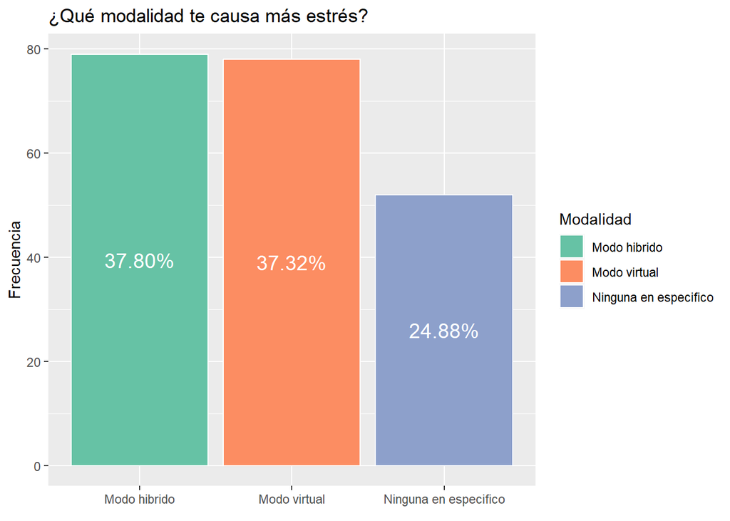

```r
table(DF$Modalidad.de.Mayor.Estres) %>% as.data.frame %>% mutate(perc = scales::percent(Freq/sum(Freq)), scale=1) %>%
  ggplot(aes(x=Var1, fill=factor(Var1), y=Freq)) +
  geom_bar(stat='identity', color = 'white') +
  geom_text(aes(label = perc), position = position_stack(vjust = 0.5), color='white', size=5) +
  ggtitle('¿Qué modalidad te causa más estrés?') + guides(fill=guide_legend(title='Modalidad')) +
  scale_fill_brewer(palette='Set2') + xlab(element_blank()) + ylab('Frecuencia')
```

Podemos observar que, en opinión de los alumnos, ambas modalidades causan similar estrés.

#### ¿En qué modalidad prefieren trabajar más de manera grupal?

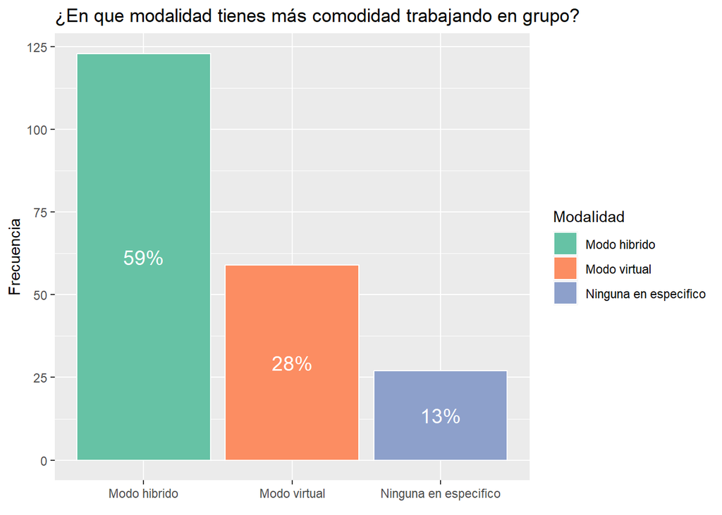

```r
table(DF$Preferencia.Trabajos.Grupales) %>%  as.data.frame %>% mutate(perc = scales::percent(Freq/sum(Freq)), scale=1) %>%
  ggplot(aes(x=Var1, fill=factor(Var1), y=Freq)) +
  geom_bar(stat='identity', color = 'white') +
  geom_text(aes(label = perc), position = position_stack(vjust = 0.5), color='white', size=5) +
  ggtitle('¿En que modalidad tienes más comodidad trabajando en grupo?') + guides(fill=guide_legend(title='Modalidad')) +
  scale_fill_brewer(palette='Set2') + xlab(element_blank()) + ylab('Frecuencia')
```

Con esta gráfica obtenemos que más del 50% de los encuestados prefieren la modalidad híbrida para trabajar grupalmente.

#### Comodidad de mascarillas

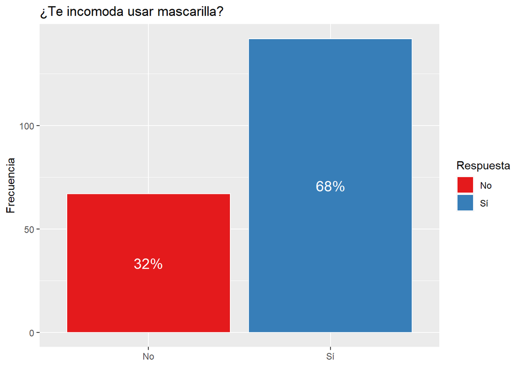

```r
table(DF$Comodidad.Mascarilla) %>%  as.data.frame %>% mutate(perc = scales::percent(Freq/sum(Freq)), scale=1) %>%
  ggplot(aes(x=Var1, fill=factor(Var1), y=Freq)) +
  geom_bar(stat='identity', color = 'white') +
  geom_text(aes(label = perc), position = position_stack(vjust = 0.5), color='white', size=5) +
  ggtitle("¿Te incomoda usar mascarilla?") + guides(fill=guide_legend(title='Respuesta')) +
  scale_fill_brewer(palette='Set1') + xlab(element_blank()) + ylab('Frecuencia')
```

Con esta gráfica buscamos analizar el porcentaje de alumnos a los que les incomoda la mascarilla. Esto se debe a que la mascarilla puede llegar a causar dolor en las orejas al estar mucho tiempo con ella y esto hace que no se pueda pr3estar atención bien en las clases híbridas.

#### Cumplimiento del reglamento de salud por parte de la Universidad

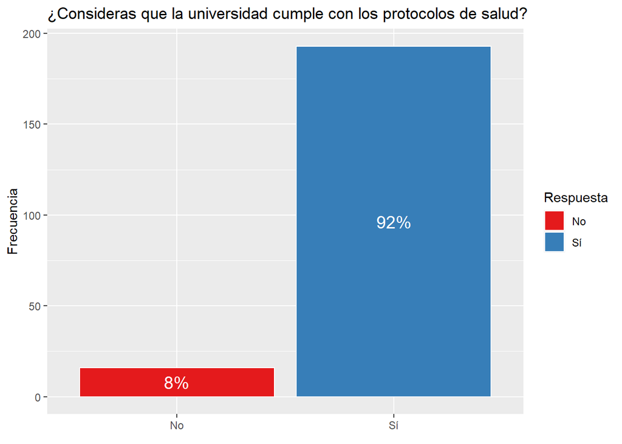

```r
table(DF$Cumplimiento.Reglamento) %>%  as.data.frame %>% mutate(perc = scales::percent(Freq/sum(Freq)), scale=1) %>%
  ggplot(aes(x=Var1, fill=factor(Var1), y=Freq)) +
  geom_bar(stat='identity', color = 'white') +
  geom_text(aes(label = perc), position = position_stack(vjust = 0.5), color='white', size=5) +
  ggtitle('¿Consideras que la universidad cumple con los protocolos de salud?') + guides(fill=guide_legend(title='Respuesta')) +
  scale_fill_brewer(palette='Set1') + xlab(element_blank()) + ylab('Frecuencia')
```

#### Comparaciones entre horas de dormir según modalidad

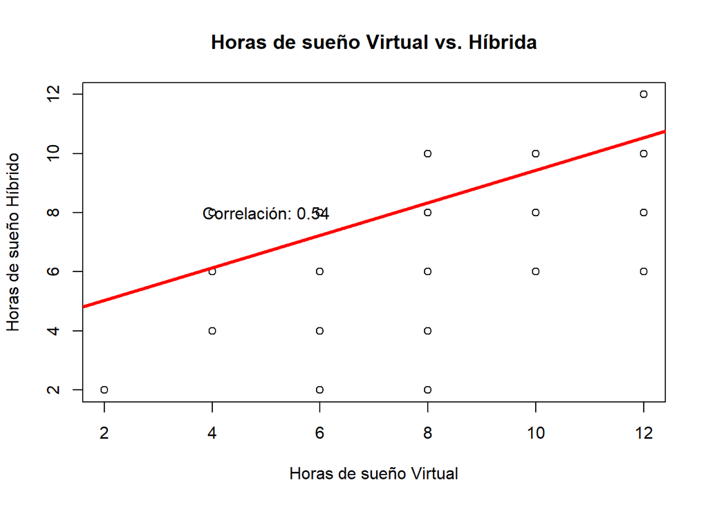

```r
Corr <- cor(x = DF$Horas.Dormir.Virtual , y = DF$Horas.Dormir.Presencial)
plot(x = DF$Horas.Dormir.Virtual, y = DF$Horas.Dormir.Presencial,
     main = "Horas de sueño Virtual vs. Híbrida", xlab = "Horas de sueño Virtual", ylab = "Horas de sueño Híbrido")
abline(lm(DF$Horas.Dormir.Virtual~DF$Horas.Dormir.Presencial), col="red",lwd="3")
text(paste("Correlación:", round(Corr, 2)), x = 5, y = 8)
```

De la grafica podemos concluir que si bien el número menor de horas de sueño del ciclo Hibrido es de 2 horas más, de la misma forma el numero mayor de horas de sueño del ciclo Virtual son 2 horas más. El ser directamente proporcional significa que la persona que duerme más en una modalidad también duerme más en la otra.

#### Distribuciones de promedios de notas según modalidad

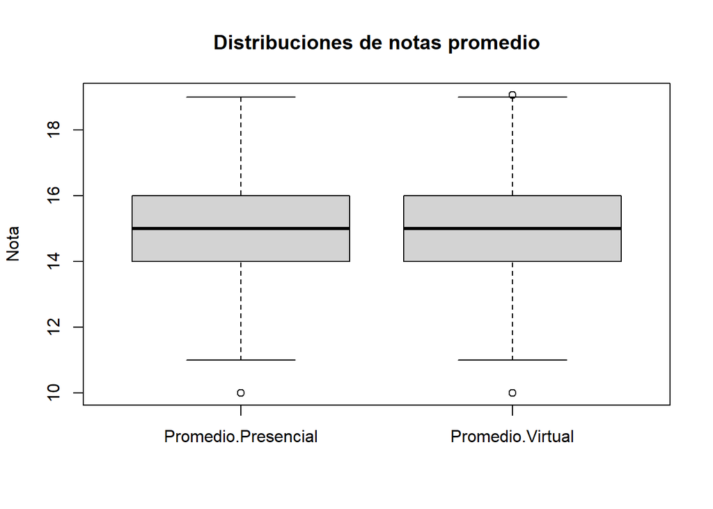

```r
DF[,c('Promedio.Presencial', 'Promedio.Virtual')] %>% boxplot(main="Distribuciones de notas promedio", ylab="Nota")
```

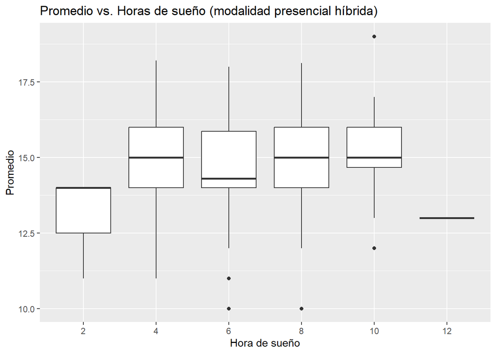

```r
DF[,c('Horas.Dormir.Presencial', 'Promedio.Presencial')] %>% na.omit %>% ggplot(aes(x=factor(Horas.Dormir.Presencial), y=Promedio.Presencial)) +
  geom_boxplot() + ggtitle('Promedio vs. Horas de sueño (modalidad presencial híbrida)') + xlab('Hora de sueño') + ylab('Promedio')
```

#### Tiempo en el transporte

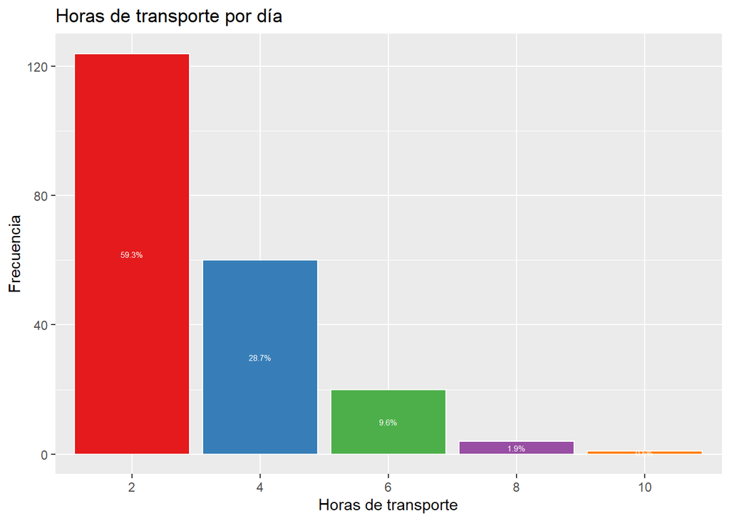

```r
table(DF$Horas.Transporte) %>%  as.data.frame %>% mutate(perc = scales::percent(Freq/sum(Freq)), scale=1) %>%
  ggplot(aes(x=Var1, fill=factor(Var1), y=Freq)) +
  geom_bar(stat='identity', color = 'white', show.legend = FALSE) +
  geom_text(aes(label = perc), position = position_stack(vjust = 0.5), color='white', size=2) +
  ggtitle('Horas de transporte por día') +
  scale_fill_brewer(palette='Set1') + xlab('Horas de transporte') + ylab('Frecuencia')
```

La mayoría de estudiantes se tardan 2 horas en el transporte. Sin embargo, el tiempo aumenta para los demás encuestados, siendo 4 horas en transporte para mas de 25 personas.

#### Tiempo empleado en ver grabaciones

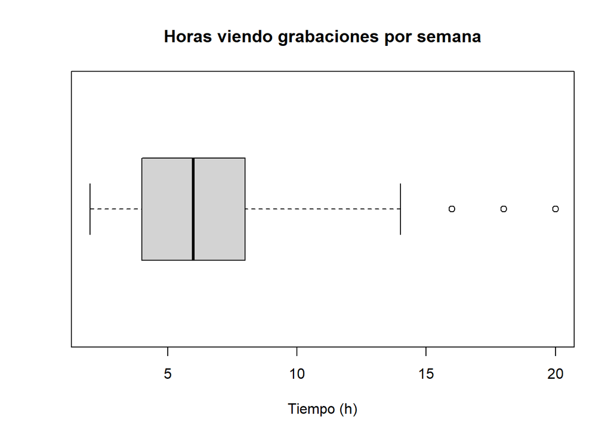

```r
boxplot(DF$Horas.en.Grabaciones, main = "Horas viendo grabaciones por semana", xlab = "Tiempo (h)", horizontal = TRUE)
```

La gráfica muestra que más de la mitad de estudiantes encuestados emplea más de 5 horas para ver las grabaciones de clase. Esto puede indicar que los alumnos de UTEC no logran concentrarse en las clases virtuales, por ende tienen que dedicar un poco más de tiempo repitiendo las grabaciones; sin embargo, comparándolo con las calificaciones, el tener que ver las grabaciones es un gran refuerzo y avance para lograr tener un mayor promedio ponderado.

# Análisis probabilístico

### Análisis descriptivo

Para cada suceso dentro de un espacio muestral de un experimento, la probabilidad de un determinado suceso es la proporción de veces que ocurre dicho suceso respecto del número total de intentos del experimento. A continuación, tenemos las probabilidades de cada valor de las variables númericas.

```r
analysisCols <- c("Horas.de.Estudio", "Horas.en.Universidad", "Horas.en.Computadora", "Horas.en.Grabaciones", "Horas.Dormir.Virtual", "Horas.Dormir.Presencial", "Horas.Transporte", "Problemas.Tecnicos", "Calificacion.Clase.Virtual", "Calificacion.Clase.Presencial")

colProbs <- c()

for(col in analysisCols){
  table(DF[,col]) %>% prop.table -> TP
  colProbs <- c(colProbs, TP)
  TP %>% round(digits = 2) %>% data.frame -> DFP
  colnames(DFP) <- c(col, "Frecuencia")
  print(DFP)
}
```

```
##   Horas.de.Estudio Frecuencia
## 1                2       0.06
## 2                4       0.15
## 3                6       0.28
## 4                8       0.16
## 5               10       0.14
## 6               12       0.10
## 7               14       0.03
## 8               16       0.08
##    Horas.en.Universidad Frecuencia
## 1                     2       0.17
## 2                     4       0.12
## 3                     6       0.14
## 4                     8       0.15
## 5                    10       0.12
```

[output cut: 70 more lines]

## Modelos de variables aleatorias

### Distribuciones normales

#### Distribuciones de promedio

En base a los siguientes histogramas que muestran las distribuciones de los valores de nota promedio (en ambas modalidades):

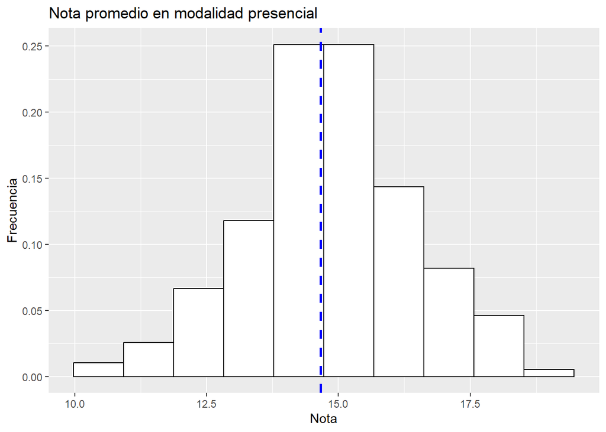

```r
ggplot(DF[!is.na(DF$Promedio.Presencial),], aes(x=Promedio.Presencial)) + geom_histogram(aes(y=..count../sum(..count..)), binwidth=0.95, color="black", fill="white") +
  geom_vline(aes(xintercept = mean(Promedio.Presencial)), color="blue", linetype="dashed", size=1) +
  ggtitle('Nota promedio en modalidad presencial') + xlab('Nota') + ylab('Frecuencia')
```

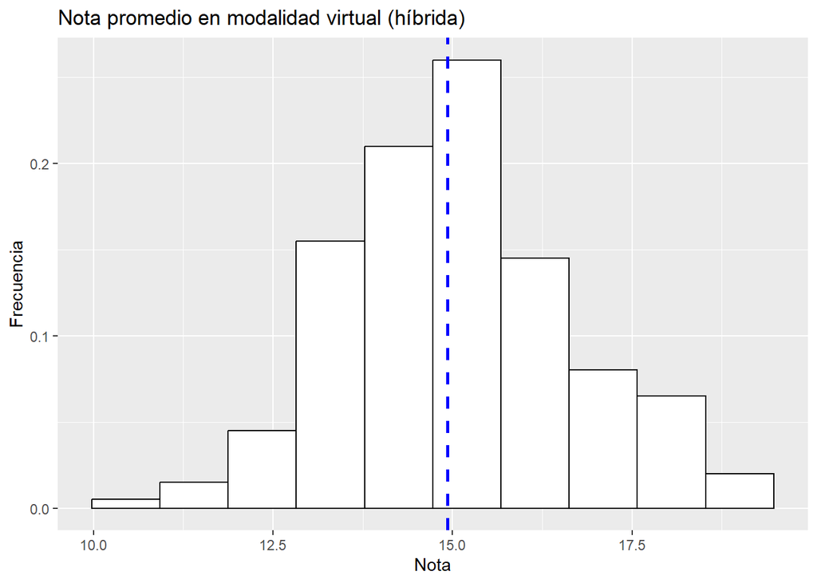

```r
ggplot(DF[!is.na(DF$Promedio.Virtual),], aes(x=Promedio.Virtual)) + geom_histogram(aes(y=..count../sum(..count..)), binwidth=0.95, color="black", fill="white") +
  geom_vline(aes(xintercept = mean(Promedio.Virtual)), color="blue", linetype="dashed", size=1) +
  ggtitle('Nota promedio en modalidad virtual (híbrida)') + xlab('Nota') + ylab('Frecuencia')
```

Buscamos ajustar distribuciones normales a estos histogramas. En ambos casos, hay un sesgo (ligeramente hacia la derecha en la modalidad presencial, y más pronunciado en la modalidad virtual). Tomando los promedios y las desviaciones estándar de estas dos variables, y asignándole un ligero sesgo a cada una de las distribuciones (usando el paquete ‘sn’, o skew-normal), podemos obtener distribuciones normales bien ajustadas a a las distribuciones reales:

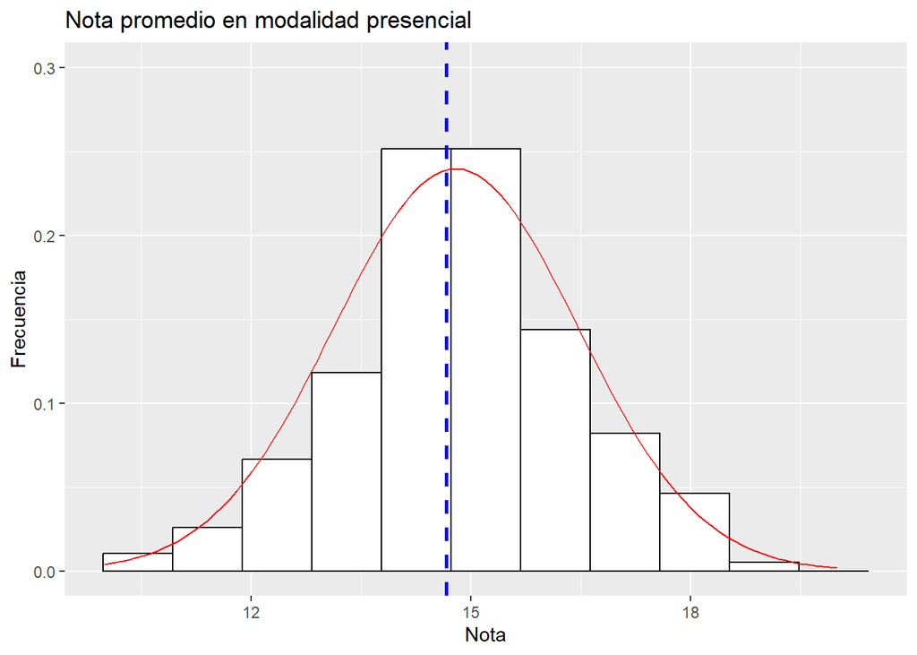

```r
nota <- seq(10, 20, 0.1)
dPres <- dsn(nota, xi=mean(DF$Promedio.Presencial, na.rm = TRUE), omega=sd(DF$Promedio.Presencial, na.rm = TRUE), alpha=0.1)
dVirt <- dsn(nota, xi=mean(DF$Promedio.Virtual, na.rm = TRUE), omega=sd(DF$Promedio.Virtual, na.rm = TRUE)/1.1, alpha=0.15)

dfNorm <- data.frame(Nota = nota, Promedio.Presencial = dPres, Promedio.Virtual = dVirt)

ggplot(DF[!is.na(DF$Promedio.Presencial),], aes(x=Promedio.Presencial)) + geom_histogram(aes(y=..count../sum(..count..)), binwidth=0.95, color="black", fill="white") +
  geom_vline(aes(xintercept = mean(Promedio.Presencial)), color="blue", linetype="dashed", size=1) +
  geom_line(data = dfNorm, aes(x=Nota, y=Promedio.Presencial), color = "red") +
  ggtitle('Nota promedio en modalidad presencial') + xlab('Nota') + ylab('Frecuencia') + ylim(0, 0.3)
```

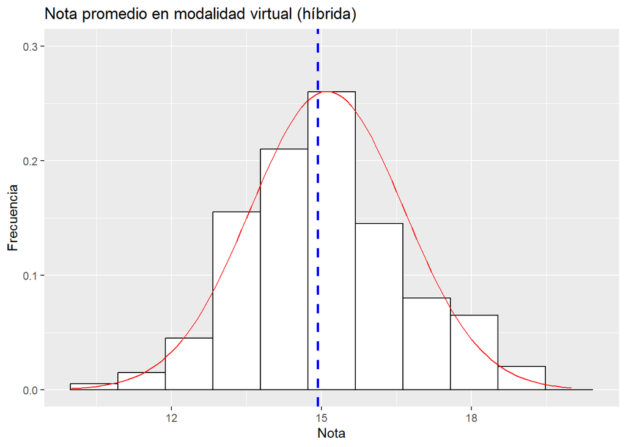

```r
ggplot(DF[!is.na(DF$Promedio.Virtual),], aes(x=Promedio.Virtual)) + geom_histogram(aes(y=..count../sum(..count..)), binwidth=0.95, color="black", fill="white") +
  geom_vline(aes(xintercept = mean(Promedio.Virtual)), color="blue", linetype="dashed", size=1) +
  geom_line(data = dfNorm, aes(x=Nota, y=Promedio.Virtual), color = "red") +
  ggtitle('Nota promedio en modalidad virtual (híbrida)') + xlab('Nota') + ylab('Frecuencia')  + ylim(0, 0.3)
```

Graficando estas dos distribuciones en una sola figura, podemos ver la diferencia:

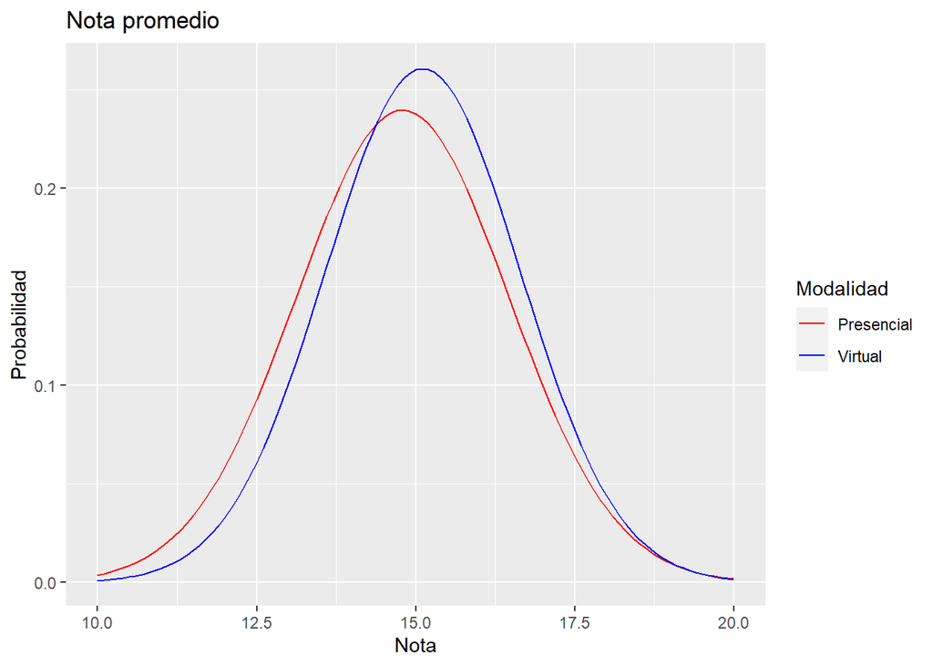

```r
ggplot(data = dfNorm, aes(x=Nota, y=Promedio.Presencial)) + geom_line(aes(x=Nota, y=Promedio.Presencial, colour = "Presencial")) +
  geom_line(aes(x=Nota, y=Promedio.Virtual, colour = "Virtual")) +
  ggtitle('Nota promedio') + xlab('Nota') + ylab('Probabilidad') +
  scale_color_manual(name = "Modalidad", values = c("Presencial" = "red", "Virtual" ="blue"))
```